[figure not shown]

# 1.4 GANITE: Generative Adversarial Network for Inference of Treatment Effects

GANITE (Yoon, Jordon, and van der Schaar, 2018) estimates individual treatment effects (ITE) by recasting the counterfactual inference problem as a generative modeling task. The core challenge it addresses is fundamental to causal inference: for any individual, only the outcome under the treatment they actually received is ever observed, while the outcome under the alternative treatment remains counterfactual and unknowable. Rather than imputing a single point estimate for this missing outcome, GANITE uses a Generative Adversarial Network to learn the full distribution of potential outcomes — capturing uncertainty while remaining grounded in the observed data distribution.

## Overview

GANITE (Yoon, Jordon, and van der Schaar, 2018) estimates individual treatment effects (ITE) by recasting counterfactual inference as a generative modeling task. The core challenge it addresses is fundamental to causal inference: for any individual, only the outcome under the treatment they actually received is observable, while the outcome under the alternative treatment remains counterfactual and unknowable. Rather than imputing a single point estimate for this missing outcome, GANITE uses a two-block GAN to learn the full distribution of potential outcomes — capturing epistemic uncertainty while remaining grounded in the observed data distribution.

In the potential outcomes framework, for each individual *i* we observe covariates $X_i$, treatment $T_i \in \{0, 1\}$, and factual outcome $Y_i^F = Y_i(T_i)$. The counterfactual outcome $Y_i^{CF} = Y_i(1 - T_i)$ is never observed. The individual treatment effect is therefore:

$$\tau_i = Y_i(1) - Y_i(0)$$

Standard regression models impute a single value for the missing $Y_i^{CF}$. GANITE instead learns a conditional generative model $p(Y(0), Y(1) \mid X)$, from which both potential outcomes and their uncertainty can be sampled.

## The two-block architecture

GANITE cleanly separates two sub-problems: *imputing missing counterfactuals* (Block 1) and *estimating treatment effects from the completed data* (Block 2). The diagram below shows GANITE's overall two-block pipeline from inputs through to the ITE estimate.

[figure not shown]

**Block 1 — the counterfactual generator.** The generator $G$ takes the observed tuple $(X_i, T_i, Y_i^F)$ together with a noise vector $Z_i \sim \mathcal{N}(0, I)$ and outputs an imputed counterfactual $\tilde{Y}_i^{CF}$. A discriminator $D$ is trained to distinguish real factual outcomes from generator-imputed counterfactuals, forcing $G$ to produce counterfactuals that are indistinguishable in distribution from real outcomes. A factual reconstruction term $\mathcal{L}_\text{factual}$ anchors the generator to the observed arm, preventing it from producing well-distributed but causally meaningless imputations.

[figure not shown]

**Block 2 — the ITE generator.** Once Block 1 has produced imputed counterfactuals for every training individual, a second generator $\hat{G}$ is trained on the now-complete dataset $\{X_i, \tilde{Y}_i^{CF}, Y_i^F\}$. Unlike $G$, it takes only covariates and noise as input — treatment and factual outcome are no longer needed because the missing data problem has been resolved. A second discriminator $\hat{D}$ distinguishes $\hat{G}$'s joint outcome pairs from the Block 1 pairs, ensuring the joint distribution of $(Y(0), Y(1))$ is respected rather than just the marginals independently. The final ITE estimate averages over multiple noise draws:

$$\hat{\tau}_i = \mathbb{E}_Z[\hat{G}(X_i, Z)_1 - \hat{G}(X_i, Z)_0]$$

**Combined training objective:**

$$\mathcal{L} = \mathcal{L}_\text{GAN}^\text{Block 1} + \alpha \cdot \mathcal{L}_\text{factual} + \mathcal{L}_\text{GAN}^\text{Block 2}$$

The shows how the three loss terms combine and the direction of gradient flow during training.

[figure not shown]

### Causal assumptions encoded

GANITE encodes three standard causal assumptions through its architecture. It assumes **ignorability** — that $T \perp (Y(0), Y(1)) \mid X$, meaning all confounding is captured in the observed covariates. It enforces **consistency** through the factual reconstruction loss, which requires $\hat{Y}_i(T_i) \approx Y_i^F$. It does not explicitly enforce **overlap**, but the adversarial training implicitly pressures the generator to produce plausible outcomes across both treatment arms for all covariate values.

## Uncertainty quantification

One of GANITE's most distinctive properties relative to deterministic estimators like TARNet or DragonNet is its native uncertainty quantification. Because both generators are stochastic, repeated forward passes through $\hat{G}$ yield a distribution over ITE estimates:

$$\{\hat{\tau}_i^{(k)}\}_{k=1}^K = \{\hat{G}(X_i, Z^{(k)})_1 - \hat{G}(X_i, Z^{(k)})_0\}_{k=1}^K$$

This distribution reflects genuine epistemic uncertainty about the unobservable counterfactual — not merely variance from model fitting. Point-estimate models cannot provide this without additional machinery such as bootstrapping or conformal prediction. GANITE's generative approach captures it directly in the model's output distribution.

### Relationship to Other Methods

| Method | Generative | Uncertainty | Latent Confounders | Architecture |
| --- | --- | --- | --- | --- |
| TARNet | No | No | No | Shared encoder + two heads |
| CFRNet | No | No | No | TARNet + MMD balancing |
| DragonNet | No | No | No | TARNet + propensity head |
| **GANITE** | **Yes (GAN)** | **Yes** | **No** | **Two-block GAN** |

GANITE is a generative model that captures uncertainty while operating in observed covariate space like TARNet, rather than learning a latent confounder structure.

### Assumptions and Limitations

**Assumptions:** - Strong ignorability holds in observed covariate space X - The GAN generator is expressive enough to capture the true distribution of potential outcomes - Sufficient sample size to train two coupled adversarial networks stably

**Limitations:** - GAN training is notoriously unstable — mode collapse, vanishing gradients, and sensitivity to hyperparameters are all practical concerns - The two-block training is sequential, meaning errors in Block 1 (counterfactual imputation) propagate into Block 2 (ITE estimation) with no mechanism to correct them - Evaluation is difficult because counterfactuals are never observed; standard loss functions cannot directly measure counterfactual accuracy on real data - Computationally expensive relative to simpler regression-based ITE estimators

## Implementation in Python

We implement GANITE with **PyDeepCausalML** and compare it to meta-learners (S, T, X, R) on the IHDP semi-synthetic dataset and a synthetic dataset with hidden confounding.

### Check and Install Required Python Packages

The following packages are used in this notebook. Install any missing packages with the cell below:

`numpy`, `pandas`, `scipy`, `torch`, `scikit-learn`, `matplotlib`, `seaborn`, `causaldata`, `pydeepcausalml`

```python
import importlib
import subprocess
import sys
from pathlib import Path

PACKAGES = [
    "numpy", "pandas", "scipy", "torch", "scikit-learn",
    "matplotlib", "seaborn", "causaldata",
]

for pkg in PACKAGES:
    mod = "sklearn" if pkg == "scikit-learn" else pkg
    try:
        importlib.import_module(mod)
    except ImportError:
        subprocess.check_call([sys.executable, "-m", "pip", "install", "-q", pkg])

try:
    import pydeepcausalml  # noqa: F401
except ImportError:
    repo_root = Path("..").resolve()
    subprocess.check_call([sys.executable, "-m", "pip", "install", "-q", "-e", str(repo_root)])

print("Packages ready.")
```

```
Packages ready.
```

### Verify imports

```python
import numpy as np
import pandas as pd
import torch
import matplotlib.pyplot as plt
import seaborn as sns
from pydeepcausalml import set_seed

print("torch:", torch.__version__)
print("cuda:", torch.cuda.is_available())
```

```
torch: 2.10.0+cu128
cuda: False
```

```python
from pathlib import Path
import os
import numpy as np
import pandas as pd
from sklearn.ensemble import RandomForestRegressor
from sklearn.linear_model import ElasticNet, LogisticRegression, LinearRegression
from sklearn.model_selection import KFold


def load_nsw_mixtape() -> pd.DataFrame:
    """Load NSW (Lalonde) mixtape data (same variables as causaldata::nsw_mixtape)."""
    try:
        import causaldata.nsw_mixtape.data as nsw_data
        dta = Path(nsw_data.__file__).parent / "nsw_mixtape.dta"
        return pd.read_stata(dta)
    except Exception:
        pass
    url = (
        "https://raw.githubusercontent.com/NickCH-K/causaldata/master/"
        "data-raw/nsw_mixtape.dta"
    )
    return pd.read_stata(url)


def propensity_elastic_net(X: np.ndarray, treatment: np.ndarray) -> np.ndarray:
    model = LogisticRegression(
        penalty="elasticnet", solver="saga", l1_ratio=0.5, max_iter=2000
    )
    model.fit(X, treatment)
    return model.predict_proba(X)[:, 1]


class SLearner:
    def __init__(self, learner: str = "ranger"):
        self.learner = learner

    def fit(self, X, t, y):
        Xt = np.column_stack([X, t])
        if self.learner == "lm":
            self.model_ = LinearRegression().fit(Xt, y)
        else:
            self.model_ = RandomForestRegressor(
                n_estimators=100, random_state=42, n_jobs=-1
            ).fit(Xt, y)
        return self

    def predict(self, X):
        y0 = self.model_.predict(np.column_stack([X, np.zeros(len(X))]))
        y1 = self.model_.predict(np.column_stack([X, np.ones(len(X))]))
        return y1 - y0


class TLearner:
    def __init__(self, learner: str = "ranger"):
        self.learner = learner

    def fit(self, X, t, y):
        t = t.astype(int)
        if self.learner == "lm":
            self.m0_ = LinearRegression().fit(X[t == 0], y[t == 0])
            self.m1_ = LinearRegression().fit(X[t == 1], y[t == 1])
        else:
            self.m0_ = RandomForestRegressor(
                n_estimators=100, random_state=42, n_jobs=-1
            ).fit(X[t == 0], y[t == 0])
            self.m1_ = RandomForestRegressor(
                n_estimators=100, random_state=42, n_jobs=-1
            ).fit(X[t == 1], y[t == 1])
        return self

    def predict(self, X):
        return self.m1_.predict(X) - self.m0_.predict(X)


class XLearner:
    def __init__(self, learner: str = "ranger"):
        self.learner = learner

    def _reg(self):
        if self.learner == "lm":
            return LinearRegression()
        return RandomForestRegressor(n_estimators=100, random_state=42, n_jobs=-1)

    def fit(self, X, t, y, p=None):
        t = t.astype(int)
        self.propensity_model_ = LogisticRegression(
            penalty="elasticnet", solver="saga", l1_ratio=0.5, max_iter=2000
        ).fit(X, t)
        m0, m1 = self._reg(), self._reg()
        m0.fit(X[t == 0], y[t == 0])
        m1.fit(X[t == 1], y[t == 1])
        d1 = y[t == 1] - m0.predict(X[t == 1])
        d0 = m1.predict(X[t == 0]) - y[t == 0]
        tau1 = self._reg().fit(X[t == 1], d1)
        tau0 = self._reg().fit(X[t == 0], d0)
        self.tau0_, self.tau1_ = tau0, tau1
        return self

    def predict(self, X):
        p = self.propensity_model_.predict_proba(X)[:, 1]
        return p * self.tau0_.predict(X) + (1 - p) * self.tau1_.predict(X)


class RLearner:
    def __init__(self, learner: str = "ranger", n_fold: int = 3):
        self.learner = learner
        self.n_fold = n_fold

    def _reg(self):
        if self.learner == "lm":
            return LinearRegression()
        return RandomForestRegressor(n_estimators=100, random_state=42, n_jobs=-1)

    def fit(self, X, t, y, p=None):
        t = t.astype(int).astype(float)
        p = propensity_elastic_net(X, t) if p is None else p
        e = t - p
        m = self._reg()
        kf = KFold(n_splits=self.n_fold, shuffle=True, random_state=42)
        y_hat = np.zeros_like(y, dtype=float)
        for tr, va in kf.split(X):
            m.fit(X[tr], y[tr])
            y_hat[va] = m.predict(X[va])
        resid = y - y_hat
        tau = self._reg()
        tau.fit(X, resid / (e + 1e-6), sample_weight=e**2)
        self.tau_ = tau
        return self

    def predict(self, X):
        return self.tau_.predict(X)


def get_cumgain(df_preds, outcome_col="y", treatment_col="w", treatment_effect_col="tau", normalize=True):
    """Cumulative gain curve (CausalML-style AUUC helper)."""
    y = df_preds[outcome_col].to_numpy()
    w = df_preds[treatment_col].to_numpy()
    tau = df_preds[treatment_effect_col].to_numpy()
    model_cols = [c for c in df_preds.columns if c not in {outcome_col, treatment_col, treatment_effect_col}]
    n = len(df_preds)
    out = {}
    for col in model_cols:
        scores = df_preds[col].to_numpy()
        order = np.argsort(-scores)
        cum = []
        treated_so_far = control_so_far = 0.0
        for i, idx in enumerate(order, start=1):
            if w[idx] == 1:
                treated_so_far += y[idx]
            else:
                control_so_far += y[idx]
            lift = treated_so_far / max((w[order[:i]] == 1).sum(), 1) - control_so_far / max(
                (w[order[:i]] == 0).sum(), 1
            )
            cum.append(lift)
        curve = np.array(cum)
        if normalize and curve[-1] != 0:
            curve = curve / np.abs(curve[-1])
        out[col] = curve
    out[treatment_effect_col] = out.get(treatment_effect_col, out[model_cols[0]])
    return pd.DataFrame(out)


def plot_gain(df_preds, outcome_col="y", treatment_col="w", treatment_effect_col="tau", model_cols=None, main="", normalize=True):
    import matplotlib.pyplot as plt

    gain = get_cumgain(df_preds, outcome_col, treatment_col, treatment_effect_col, normalize)
    model_cols = model_cols or [c for c in gain.columns]
    plt.figure(figsize=(8, 5))
    for col in model_cols:
        if col in gain.columns:
            plt.plot(gain[col].values, label=col)
    plt.xlabel("Population fraction targeted")
    plt.ylabel("Cumulative gain" + (" (normalized)" if normalize else ""))
    plt.title(main)
    plt.legend()
    plt.tight_layout()
    plt.show()


def load_ihdp(replications: int = 2, random_state: int = 1):
    base_url = "https://raw.githubusercontent.com/uber/causalml/master/docs/examples/data"
    cols = ["treatment", "y_factual", "y_cfactual", "mu0", "mu1"] + [f"X{i}" for i in range(25)]
    parts = []
    for i in range(1, 10):
        url = f"{base_url}/ihdp_npci_{i}.csv"
        tmp = pd.read_csv(url, header=None)
        tmp.columns = cols[: tmp.shape[1]]
        parts.append(tmp)
    df = pd.concat(parts, ignore_index=True)
    if replications > 1:
        df = pd.concat([df] * replications, ignore_index=True)
    binfeats = [f"X{i}" for i in range(6, 25)]
    contfeats = [f"X{i}" for i in range(6)]
    xcols = binfeats + contfeats
    X = df[xcols].to_numpy(dtype=float)
    treatment = df["treatment"].to_numpy(dtype=int)
    y = df["y_factual"].to_numpy(dtype=float)
    tau = np.where(
        treatment == 1,
        df["y_factual"] - df["y_cfactual"],
        df["y_cfactual"] - df["y_factual"],
    )
    n = len(X)
    rng = np.random.default_rng(random_state)
    val_idx = rng.choice(n, size=int(0.2 * n), replace=False)
    train_idx = np.setdiff1d(np.arange(n), val_idx)
    return df, X, treatment, y, tau, train_idx, val_idx


def simulate_hidden_confounder(n=2000, p=5, sigma=1.0, adj=0, random_state=42):
    """Synthetic DGP with latent confounder (CausalML-style benchmark)."""
    rng = np.random.default_rng(random_state)
    z = rng.normal(size=n)
    X = np.column_stack([z + rng.normal(scale=sigma, size=n) for _ in range(p)])
    e = 1 / (1 + np.exp(-(adj + 0.5 * z)))
    w = rng.binomial(1, e)
    b = 2 * z + rng.normal(scale=sigma, size=n)
    tau = 0.5 + 0.3 * z
    y = b + w * tau + rng.normal(scale=sigma, size=n)
    return {"X": X, "y": y, "w": w, "tau": tau, "b": b, "e": e}


def result_table(df_preds, tau_true):
    model_cols = [c for c in ["S", "T", "X", "R", "GANITE", "CEVAE"] if c in df_preds.columns]
    methods = model_cols + ["actual"]
    ate = [df_preds[m].mean() for m in model_cols] + [float(tau_true.mean())]
    mae = [float(np.mean(np.abs(df_preds[m] - tau_true))) for m in model_cols] + [np.nan]
    gain = get_cumgain(df_preds)
    auuc = [float(gain[m].mean()) if m in gain.columns else np.nan for m in model_cols]
    auuc.append(float(gain["tau"].mean()) if "tau" in gain.columns else np.nan)
    return pd.DataFrame({"Method": methods, "ATE": ate, "MAE": mae, "AUUC": auuc})


def synthetic_summary(preds, tau_ref, actual_ate):
    rows = []
    for name, p in preds.items():
        rows.append({
            "Method": name,
            "ATE": p.mean(),
            "MSE": np.mean((p - tau_ref) ** 2),
            "AbsPctErrorATE": abs(p.mean() / actual_ate - 1) if actual_ate != 0 else np.nan,
        })
    rows.append({"Method": "Actuals", "ATE": actual_ate, "MSE": np.nan, "AbsPctErrorATE": np.nan})
    return pd.DataFrame(rows)

import os
from pydeepcausalml.effect import GANITE

RUN_FAST = os.getenv("PYDEEPCAUSALML_FAST_RENDER", "true").lower() == "true"
set_seed(42)
```

## Fit GANITE on the IHDP dataset

```python
df, X, treatment, y, tau, train_idx, val_idx = load_ihdp(
    replications=2 if RUN_FAST else 10, random_state=1
)
X_train, X_val = X[train_idx], X[val_idx]
treatment_train, treatment_val = treatment[train_idx], treatment[val_idx]
y_train, y_val = y[train_idx], y[val_idx]
tau_train, tau_val = tau[train_idx], tau[val_idx]
print("Train size:", len(train_idx), "| Val size:", len(val_idx))
```

```
Train size: 10757 | Val size: 2689
```

### Fit GANITE model

```python
gn = GANITE(
    h_dim=25 if RUN_FAST else 50,
    epochs=100 if RUN_FAST else 500,
    batch_size=128 if RUN_FAST else 64,
    lr=1e-4,
    random_state=42,
    verbose=not RUN_FAST,
    log_every=20,
).fit(X_train, treatment_train, y_train)

ite_train_ganite = gn.predict_cate(X_train)
ite_val_ganite = gn.predict_cate(X_val)
print("GANITE — ATE (train):", round(ite_train_ganite.mean(), 4),
      "| ATE (val):", round(ite_val_ganite.mean(), 4))
```

```
GANITE — ATE (train): -4.0682 | ATE (val): -4.0811
```

### Fit Meta-learners

```python
p_train = propensity_elastic_net(X_train, treatment_train)
n_fold_meta = 3 if RUN_FAST else 5
sl = SLearner("ranger").fit(X_train, treatment_train, y_train)
tl = TLearner("ranger").fit(X_train, treatment_train, y_train)
xl = XLearner("ranger").fit(X_train, treatment_train, y_train, p=p_train)
rl = RLearner("ranger", n_fold=n_fold_meta).fit(X_train, treatment_train, y_train, p=p_train)
```

### Model results comparison — Training

|  | Method | ATE | MAE | AUUC |
| --- | --- | --- | --- | --- |
| 0 | S | 4.8554 | 4.9433 | 1.5687 |
| 1 | T | 4.8548 | 5.0433 | 1.6087 |
| 2 | X | 4.5237 | 4.6198 | 1.5756 |
| 3 | R | -0.0918 | 9.7569 | 0.7009 |
| 4 | GANITE | -4.0682 | 10.0852 | 1.3401 |
| 5 | actual | 4.6847 | NaN | 1.5687 |

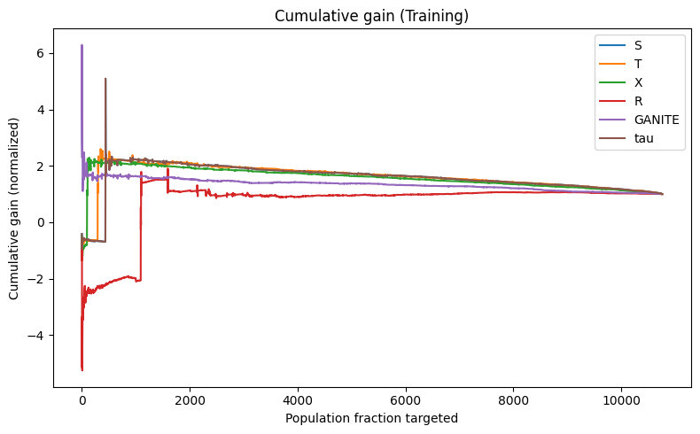

```python
df_preds_train = pd.DataFrame({
    "S": sl.predict(X_train), "T": tl.predict(X_train),
    "X": xl.predict(X_train), "R": rl.predict(X_train),
    "GANITE": ite_train_ganite, "tau": tau_train,
    "w": treatment_train, "y": y_train,
})

display(result_table(df_preds_train, tau_train).round(4))
plot_gain(df_preds_train, main="Cumulative gain (Training)")
```

#### Validation

|  | Method | ATE | MAE | AUUC |
| --- | --- | --- | --- | --- |
| 0 | S | 4.7509 | 5.0524 | 0.5002 |
| 1 | T | 4.7244 | 5.2091 | 0.4130 |
| 2 | X | 4.4373 | 4.7426 | 0.7792 |
| 3 | R | -0.5722 | 10.4925 | 0.6608 |
| 4 | GANITE | -4.0811 | 10.2138 | 1.1842 |
| 5 | actual | 5.0600 | NaN | 0.5002 |

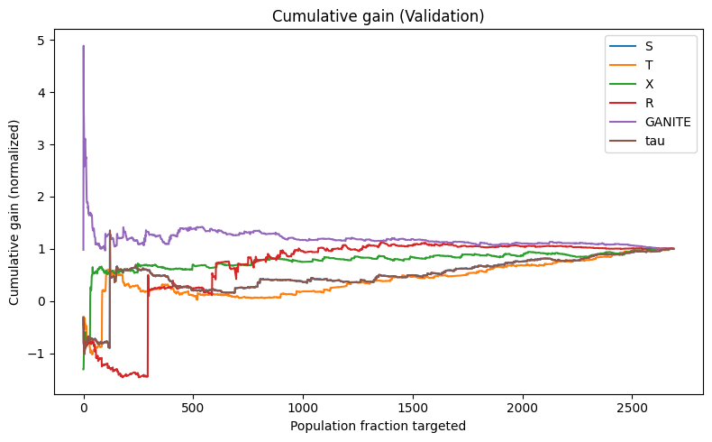

```python
df_preds_val = pd.DataFrame({
    "S": sl.predict(X_val), "T": tl.predict(X_val),
    "X": xl.predict(X_val), "R": rl.predict(X_val),
    "GANITE": ite_val_ganite, "tau": tau_val,
    "w": treatment_val, "y": y_val,
})
display(result_table(df_preds_val, tau_val).round(4))
plot_gain(df_preds_val, main="Cumulative gain (Validation)")
```

## Fit GANITE on Synthetic Data with Hidden Confounding

```python
n_syn = 2000 if RUN_FAST else 10000
d_syn = simulate_hidden_confounder(n=n_syn, p=5, sigma=1.0, adj=0)
X_syn, y_syn, w_syn, tau_syn = d_syn["X"], d_syn["y"], d_syn["w"], d_syn["tau"]
rng = np.random.default_rng(123)
val_idx = rng.choice(len(X_syn), size=int(0.2 * len(X_syn)), replace=False)
train_idx = np.setdiff1d(np.arange(len(X_syn)), val_idx)
X_syn_tr, X_syn_val = X_syn[train_idx], X_syn[val_idx]
y_syn_tr, y_syn_val = y_syn[train_idx], y_syn[val_idx]
w_syn_tr, w_syn_val = w_syn[train_idx], w_syn[val_idx]
tau_syn_tr, tau_syn_val = tau_syn[train_idx], tau_syn[val_idx]
p_syn_tr = propensity_elastic_net(X_syn_tr, w_syn_tr)
```

```python
gn_syn = GANITE(
    h_dim=25 if RUN_FAST else 50,
    epochs=80 if RUN_FAST else 300,
    batch_size=128 if RUN_FAST else 64,
    random_state=42,
).fit(X_syn_tr, w_syn_tr, y_syn_tr)

preds_syn_train, preds_syn_valid = {"GANITE": gn_syn.predict_cate(X_syn_tr)}, {
    "GANITE": gn_syn.predict_cate(X_syn_val)
}
for learner_name in ["lm", "ranger"]:
    sl_s = SLearner(learner_name).fit(X_syn_tr, w_syn_tr, y_syn_tr)
    tl_s = TLearner(learner_name).fit(X_syn_tr, w_syn_tr, y_syn_tr)
    xl_s = XLearner(learner_name).fit(X_syn_tr, w_syn_tr, y_syn_tr, p=p_syn_tr)
    rl_s = RLearner(learner_name, n_fold=n_fold_meta).fit(X_syn_tr, w_syn_tr, y_syn_tr, p=p_syn_tr)
    for meta, est in [("S", sl_s), ("T", tl_s), ("X", xl_s), ("R", rl_s)]:
        label = f"{meta} Learner ({learner_name})"
        preds_syn_train[label] = est.predict(X_syn_tr)
        preds_syn_valid[label] = est.predict(X_syn_val)
```

```
Synthetic — Training summary:
```

|  | Method | ATE | MSE | AbsPctErrorATE |
| --- | --- | --- | --- | --- |
| 0 | GANITE | 0.3692 | 0.1870 | 0.2335 |
| 1 | S Learner (lm) | 0.6784 | 0.1277 | 0.4084 |
| 2 | T Learner (lm) | 0.6790 | 0.0790 | 0.4098 |
| 3 | X Learner (lm) | 0.6790 | 0.0790 | 0.4098 |
| 4 | R Learner (lm) | 0.6975 | 0.0911 | 0.4483 |
| 5 | S Learner (ranger) | 0.4012 | 0.3046 | 0.1670 |
| 6 | T Learner (ranger) | 0.7103 | 1.6031 | 0.4747 |
| 7 | X Learner (ranger) | 0.6665 | 0.6906 | 0.3837 |
| 8 | R Learner (ranger) | 0.8067 | 6.6625 | 0.6749 |
| 9 | Actuals | 0.4816 | NaN | NaN |

```
Synthetic — Validation summary:
```

|  | Method | ATE | MSE | AbsPctErrorATE |
| --- | --- | --- | --- | --- |
| 0 | GANITE | 0.3628 | 0.1942 | 0.2608 |
| 1 | S Learner (lm) | 0.6784 | 0.1306 | 0.3823 |
| 2 | T Learner (lm) | 0.6931 | 0.0785 | 0.4123 |
| 3 | X Learner (lm) | 0.6931 | 0.0785 | 0.4123 |
| 4 | R Learner (lm) | 0.7144 | 0.0910 | 0.4558 |
| 5 | S Learner (ranger) | 0.3980 | 0.1826 | 0.1889 |
| 6 | T Learner (ranger) | 0.6833 | 0.7911 | 0.3924 |
| 7 | X Learner (ranger) | 0.6436 | 0.3848 | 0.3115 |
| 8 | R Learner (ranger) | 0.7747 | 1.3331 | 0.5787 |
| 9 | Actuals | 0.4908 | NaN | NaN |

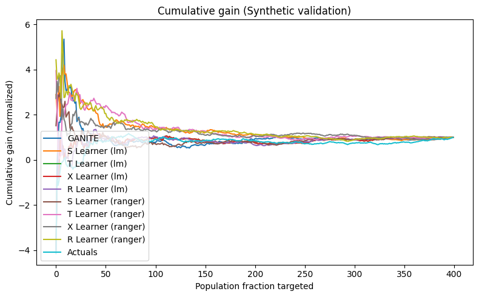

```python
print("Synthetic — Training summary:")
display(synthetic_summary(preds_syn_train, tau_syn_tr, tau_syn_tr.mean()).round(4))
print("Synthetic — Validation summary:")
display(synthetic_summary(preds_syn_valid, tau_syn_val, tau_syn_val.mean()).round(4))

df_syn_val = pd.DataFrame(preds_syn_valid)
df_syn_val["tau"] = tau_syn_val
df_syn_val["w"] = w_syn_val
df_syn_val["y"] = y_syn_val
df_syn_val["Actuals"] = tau_syn_val
plot_gain(df_syn_val, model_cols=list(preds_syn_valid.keys()) + ["Actuals"],
          main="Cumulative gain (Synthetic validation)")
```

## Summary and Conclusion

GANITE reframes ITE estimation as learning the joint distribution of potential outcomes under a GAN framework.

- Yoon, J., Jordon, J., & van der Schaar, M. (2018). [GANITE](https://arxiv.org/abs/1809.00916). ICLR.